# Analyse des retards de livraison – DataCo

Author

Christian Nguemewe

## Chargement des données

```r
data <- read.csv("data/DataCoSupplyChainDataset.csv", fileEncoding = "latin1")
```

```r
dim(data)
```

```
[1] 180519     53
```

```r
nrow(data)
```

```
[1] 180519
```

```r
names(data)
```

```
 [1] "Type"                          "Days.for.shipping..real."
 [3] "Days.for.shipment..scheduled." "Benefit.per.order"
 [5] "Sales.per.customer"            "Delivery.Status"
 [7] "Late_delivery_risk"            "Category.Id"
 [9] "Category.Name"                 "Customer.City"
[11] "Customer.Country"              "Customer.Email"
[13] "Customer.Fname"                "Customer.Id"
[15] "Customer.Lname"                "Customer.Password"
[17] "Customer.Segment"              "Customer.State"
[19] "Customer.Street"               "Customer.Zipcode"
[21] "Department.Id"                 "Department.Name"
[23] "Latitude"                      "Longitude"
[25] "Market"                        "Order.City"
[27] "Order.Country"                 "Order.Customer.Id"
[29] "order.date..DateOrders."       "Order.Id"
[31] "Order.Item.Cardprod.Id"        "Order.Item.Discount"
[33] "Order.Item.Discount.Rate"      "Order.Item.Id"
[35] "Order.Item.Product.Price"      "Order.Item.Profit.Ratio"
[37] "Order.Item.Quantity"           "Sales"
[39] "Order.Item.Total"              "Order.Profit.Per.Order"
[41] "Order.Region"                  "Order.State"
[43] "Order.Status"                  "Order.Zipcode"
[45] "Product.Card.Id"               "Product.Category.Id"
[47] "Product.Description"           "Product.Image"
[49] "Product.Name"                  "Product.Price"
[51] "Product.Status"                "shipping.date..DateOrders."
[53] "Shipping.Mode"
```

```r
head(data)
```

```
      Type Days.for.shipping..real. Days.for.shipment..scheduled.
1    DEBIT                        3                             4
2 TRANSFER                        5                             4
3     CASH                        4                             4
4    DEBIT                        3                             4
5  PAYMENT                        2                             4
6 TRANSFER                        6                             4
  Benefit.per.order Sales.per.customer   Delivery.Status Late_delivery_risk
1             91.25             314.64  Advance shipping                  0
2           -249.09             311.36     Late delivery                  1
3           -247.78             309.72  Shipping on time                  0
4             22.86             304.81  Advance shipping                  0
5            134.21             298.25  Advance shipping                  0
6             18.58             294.98 Shipping canceled                  0
  Category.Id  Category.Name Customer.City Customer.Country Customer.Email
```

[output cut: 76 more lines]

```r
table(data$Delivery.Status)
```

```
 Advance shipping     Late delivery Shipping canceled  Shipping on time
            41592             98977              7754             32196
```

```r
table(data$Late_delivery_risk)
```

```
    0     1
81542 98977
```

```r
View(data)
```

```r
View(data[, 1:7])
```

```r
petit <- data[, c("Days.for.shipping..real.", "Days.for.shipment..scheduled.", "Delivery.Status", "Shipping.Mode")]
head(petit, 20)
```

```
   Days.for.shipping..real. Days.for.shipment..scheduled.   Delivery.Status
1                         3                             4  Advance shipping
2                         5                             4     Late delivery
3                         4                             4  Shipping on time
4                         3                             4  Advance shipping
5                         2                             4  Advance shipping
6                         6                             4 Shipping canceled
7                         2                             1     Late delivery
8                         2                             1     Late delivery
9                         3                             2     Late delivery
10                        2                             1     Late delivery
11                        6                             2 Shipping canceled
12                        5                             2     Late delivery
13                        4                             2     Late delivery
14                        2                             1     Late delivery
```

[output cut: 27 more lines]

```r
table(data$Shipping.Mode, data$Delivery.Status)
```

```
                 Advance shipping Late delivery Shipping canceled
  First Class                   0         26513              1301
  Same Day                      0          4454               444
  Second Class                  0         26987              1410
  Standard Class            41592         41023              4599

                 Shipping on time
  First Class                   0
  Same Day                   4839
  Second Class               6819
  Standard Class            20538
```

```r
round(prop.table(table(data$Shipping.Mode, data$Delivery.Status), 1) * 100, 1)
```

```
                 Advance shipping Late delivery Shipping canceled
  First Class                 0.0          95.3               4.7
  Same Day                    0.0          45.7               4.6
  Second Class                0.0          76.6               4.0
  Standard Class             38.6          38.1               4.3

                 Shipping on time
  First Class                 0.0
  Same Day                   49.7
  Second Class               19.4
  Standard Class             19.1
```

```r
aggregate(
  cbind(
    prevus = Days.for.shipment..scheduled.,
    reels  = Days.for.shipping..real.
  ) ~ Shipping.Mode,
  data = data,
  FUN = function(x) round(mean(x), 2)

)
```

```
   Shipping.Mode prevus reels
1    First Class      1  2.00
2       Same Day      0  0.48
3   Second Class      2  3.99
4 Standard Class      4  4.00
```

```r
aggregate(
  cbind(
    prevus = Days.for.shipment..scheduled.,
    reels  = Days.for.shipping..real.
  ) ~ Shipping.Mode,
  data = data,
  FUN = function(x) round(mean(x), 2)
)
```

```
   Shipping.Mode prevus reels
1    First Class      1  2.00
2       Same Day      0  0.48
3   Second Class      2  3.99
4 Standard Class      4  4.00
```

## Conclusion – Question 1 : d’où viennent les retards ?

**Constat.** Sur 180 519 commandes, 54,83 % sont livrées en retard. Le taux varie fortement selon le mode d’envoi :

| Mode d’envoi | Délai promis | Délai réel | Taux de retard |
| --- | --- | --- | --- |
| First Class | 1 jour | 2 jours | 95,3 % |
| Second Class | 2 jours | 4 jours | 76,6 % |
| Same Day | 0 jour | 0,5 jour | 45,7 % |
| Standard Class | 4 jours | 4 jours | 38,1 % |

**Interprétation.** Les retards de First Class et Second Class ne viennent pas d’une livraison lente, mais d’une promesse irréaliste : ces deux modes livrent régulièrement en 2 et 4 jours. Same Day prouve qu’une livraison le jour même est possible, mais échoue presque une fois sur deux. Standard Class respecte son délai en moyenne, mais 38 % de ses envois restent en retard.

**Recommandations.** 1. Annoncer 2 jours pour First Class et 4 jours pour Second Class, conformément aux délais réels observés. 2. Pour Same Day, conserver la promesse et rechercher pourquoi près d’une commande sur deux n’est pas livrée le jour même (heure de commande, région, entrepôt).

*Limite : ces chiffres incluent les 7 754 commandes annulées ; ils seront recalculés sans elles.*

### Question 2

```r
livrees <- data[data$Delivery.Status != "Shipping canceled", ]
livrees
```

```
         Type Days.for.shipping..real. Days.for.shipment..scheduled.
1       DEBIT                        3                             4
2    TRANSFER                        5                             4
3        CASH                        4                             4
4       DEBIT                        3                             4
5     PAYMENT                        2                             4
7       DEBIT                        2                             1
8    TRANSFER                        2                             1
9        CASH                        3                             2
10       CASH                        2                             1
12   TRANSFER                        5                             2
13   TRANSFER                        4                             2
14      DEBIT                        2                             1
15   TRANSFER                        2                             1
16      DEBIT                        2                             1
```

[output cut: 30178 more lines]

```r
nrow(livrees)
```

```
[1] 172765
```

```r
table(livrees$Delivery.Status)
```

```
Advance shipping    Late delivery Shipping on time
           41592            98977            32196
```

```r
round(prop.table(table( livrees$Shipping.Mode, livrees$Delivery.Status ), 1) * 100, 1)
```

```
                 Advance shipping Late delivery Shipping on time
  First Class                 0.0         100.0              0.0
  Same Day                    0.0          47.9             52.1
  Second Class                0.0          79.8             20.2
  Standard Class             40.3          39.8             19.9
```

#### Interpretation

Les commandes annulées ne faisaient pas partie des retards. En les retirant, le nombre de livraisons diminue mais le nombre de retards reste identique : le taux de retard augmente donc dans les quatre modes d’envoi .les nouveaux taux deviennent donc (57,3 % global ; First 100 %, Second 79,8 %, Same Day 47,9 %, Standard 39,8 %).

### Question 3

```r
taux <- prop.table(table( livrees$Shipping.Mode, livrees$Delivery.Status ), 1)
```

```r
retards <- taux[, "Late delivery"]
retards
```

```
   First Class       Same Day   Second Class Standard Class
     1.0000000      0.4792855      0.7982902      0.3976908
```

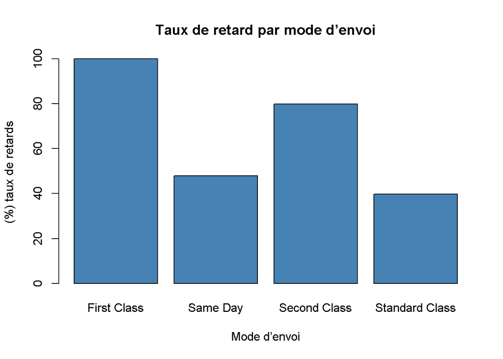

```r
barplot(retards * 100,
        xlab = "Mode d’envoi",
       ylab = "(%) taux de retards",
       main = "Taux de retard par mode d’envoi",
       col = "steelblue")
```

```r
sameday <- livrees[livrees$Shipping.Mode == "Same Day", ]
sameday
```

```
          Type Days.for.shipping..real. Days.for.shipment..scheduled.
20     PAYMENT                        0                             0
21    TRANSFER                        0                             0
39       DEBIT                        1                             0
41     PAYMENT                        1                             0
42       DEBIT                        1                             0
388   TRANSFER                        0                             0
389    PAYMENT                        0                             0
390       CASH                        0                             0
448    PAYMENT                        1                             0
449      DEBIT                        1                             0
450      DEBIT                        1                             0
451      DEBIT                        1                             0
452       CASH                        1                             0
454      DEBIT                        1                             0
```

[output cut: 32065 more lines]

```r
nrow(sameday)
```

```
[1] 9293
```

```r
taux1 <- prop.table(table(sameday$Market, sameday$Delivery.Status ), 1)
```

```r
retards1 <- taux1[, "Late delivery"]
retards1
```

```
      Africa       Europe        LATAM Pacific Asia         USCA
   0.4637224    0.4881860    0.5035601    0.4538642    0.4642857
```

## Same Day : la région explique-t-elle les retards ?

Pour les commandes Same Day, le taux de retard est presque le même dans toutes les régions : Africa 46,4 %, Europe 48,8 %, LATAM 50,4 %, Pacific Asia 45,4 % et USCA 46,4 %. Il varie seulement entre 45 et 50 %.

La région n’explique donc pas les retards Same Day. La cause est à chercher ailleurs (par exemple l’organisation interne), ce qui demande une autre analyse.

```r
taux2 <- prop.table(table(sameday$Department.Name, sameday$Delivery.Status ), 1)
```

```r
retards_d <- taux2[, "Late delivery"]
retards_d
```

```
           Apparel          Book Shop         Discs Shop           Fan Shop
         0.4708432          0.7619048          0.5408163          0.4820498
           Fitness           Footwear               Golf Health and Beauty
         0.4841270          0.4751678          0.4814378          0.3846154
          Outdoors           Pet Shop         Technology
         0.4641350          0.6052632          0.4264706
```

```r
table(sameday$Department.Name)
```

```
           Apparel          Book Shop         Discs Shop           Fan Shop
              2538                 42                 98               3454
           Fitness           Footwear               Golf Health and Beauty
               126                745               1697                 13
          Outdoors           Pet Shop         Technology
               474                 38                 68
```

#### Same Day : le type de produit explique-t-il les retards ?

Book Shop (76 %) et Pet Shop (60 %) ont des taux élevés, mais sur trop peu de commandes (42 et 38) pour être sûrs. C’est un signal à surveiller, pas une preuve. Les grands rayons sont tous autour de 47-48 %, donc le type de produit n’explique pas les retards Same Day.

```r
table(sameday$Customer.Segment)
```

```
   Consumer   Corporate Home Office
       4923        2824        1546
```

```r
taux3 <- prop.table(table(sameday$Customer.Segment, sameday$Delivery.Status ), 1)
```

```r
retards_s <- taux3[, "Late delivery"]
retards_s
```

```
   Consumer   Corporate Home Office
  0.4860857   0.4865439   0.4443726
```

#### Interpretation

Pour les livraisons Same Day, le taux de retard varie peu selon le type de client : 48,6 % pour Consumer, 48,7 % pour Corporate et 44,4 % pour Home Office. Le segment de client n’explique donc pas les retards. Home Office est légèrement en dessous, mais près d’une commande sur deux y reste en retard.

```r
names(sameday)
```

```
 [1] "Type"                          "Days.for.shipping..real."
 [3] "Days.for.shipment..scheduled." "Benefit.per.order"
 [5] "Sales.per.customer"            "Delivery.Status"
 [7] "Late_delivery_risk"            "Category.Id"
 [9] "Category.Name"                 "Customer.City"
[11] "Customer.Country"              "Customer.Email"
[13] "Customer.Fname"                "Customer.Id"
[15] "Customer.Lname"                "Customer.Password"
[17] "Customer.Segment"              "Customer.State"
[19] "Customer.Street"               "Customer.Zipcode"
[21] "Department.Id"                 "Department.Name"
[23] "Latitude"                      "Longitude"
[25] "Market"                        "Order.City"
[27] "Order.Country"                 "Order.Customer.Id"
[29] "order.date..DateOrders."       "Order.Id"
[31] "Order.Item.Cardprod.Id"        "Order.Item.Discount"
[33] "Order.Item.Discount.Rate"      "Order.Item.Id"
[35] "Order.Item.Product.Price"      "Order.Item.Profit.Ratio"
[37] "Order.Item.Quantity"           "Sales"
[39] "Order.Item.Total"              "Order.Profit.Per.Order"
[41] "Order.Region"                  "Order.State"
[43] "Order.Status"                  "Order.Zipcode"
[45] "Product.Card.Id"               "Product.Category.Id"
[47] "Product.Description"           "Product.Image"
[49] "Product.Name"                  "Product.Price"
[51] "Product.Status"                "shipping.date..DateOrders."
[53] "Shipping.Mode"
```

```r
head(sameday$order.date..DateOrders.)
```

```
[1] "1/13/2018 6:09"  "1/13/2018 5:48"  "1/12/2018 23:30" "1/12/2018 22:48"
[5] "1/12/2018 22:27" "1/12/2018 11:14"
```

```r
sameday$date_cmd <- sameday$order.date..DateOrders <- as.Date(
  sameday$order.date..DateOrders,
  format = "%m/%d/%Y %H:%M"
)
```

```r
head(sameday$date_cmd)
```

```
[1] "2018-01-13" "2018-01-13" "2018-01-12" "2018-01-12" "2018-01-12"
[6] "2018-01-12"
```

```r
sameday$mois <- format(sameday$date_cmd, "%m")
```

```r
table(sameday$mois)
```

```
  01   02   03   04   05   06   07   08   09   10   11   12
 921  768  824  700  817  727 1046  770  753  703  595  669
```

```r
taux4 <- prop.table(table(sameday$mois, sameday$Delivery.Status ), 1)
```

```r
retards_mois <- taux4[, "Late delivery"]
retards_mois
```

```
       01        02        03        04        05        06        07        08
0.4853420 0.4765625 0.5024272 0.4642857 0.4944920 0.5075653 0.4359465 0.5207792
       09        10        11        12
0.4674635 0.4822191 0.4588235 0.4603886
```

#### Interpretation

Pour les livraisons Same Day, le taux de retard varie de 43,6 % (juillet) à 52,1 % (août) selon le mois, et la plupart des mois se situent entre 46 et 50 %. Aucune saison ne se détache nettement : le mois n’explique donc pas les retards Same Day

### Depense

```r
aggregate(
  Benefit.per.order ~ Delivery.Status,
  data = data,
  FUN = function(x) round(mean(x), 2)


)
```

```
    Delivery.Status Benefit.per.order
1  Advance shipping             22.49
2     Late delivery             21.62
3 Shipping canceled             20.70
4  Shipping on time             22.71
```

#### Interpretation

Le bénéfice par commande est presque identique quel que soit le statut de livraison (de 20,70 € à 22,71 €). Mais ce bénéfice est enregistré à la vente : même les commandes annulées en affichent un. Ces données ne permettent donc pas de mesurer le coût réel des retards

```r
retards <- subset(data, Delivery.Status == "Late delivery")
retards
```

```
         Type Days.for.shipping..real. Days.for.shipment..scheduled.
2    TRANSFER                        5                             4
7       DEBIT                        2                             1
8    TRANSFER                        2                             1
9        CASH                        3                             2
10       CASH                        2                             1
12   TRANSFER                        5                             2
13   TRANSFER                        4                             2
14      DEBIT                        2                             1
15   TRANSFER                        2                             1
16      DEBIT                        2                             1
17    PAYMENT                        5                             2
18       CASH                        2                             1
19      DEBIT                        2                             1
22   TRANSFER                        5                             4
```

[output cut: 32065 more lines]

```r
retards$ecart <- retards$Days.for.shipping..real. -
                 retards$Days.for.shipment..scheduled.
summary(retards$ecart)
```

```
   Min. 1st Qu.  Median    Mean 3rd Qu.    Max.
  1.000   1.000   1.000   1.618   2.000   4.000
```

```r
moyennes <- tapply(retards$ecart, retards$Market,
                   function(x) round(mean(x), 2))
moyennes
```

```
      Africa       Europe        LATAM Pacific Asia         USCA
        1.60         1.62         1.62         1.62         1.62
```

```r
sort(moyennes,decreasing = TRUE)
```

```
      Europe        LATAM Pacific Asia         USCA       Africa
        1.62         1.62         1.62         1.62         1.60
```

#### Iterpretation

Parmi les commandes en retard, le retard moyen est presque identique dans tous les marchés (de 1,60 à 1,62 jour). La distance ou la région de destination n’explique donc pas la durée des retards. L’explication est plutôt à chercher dans l’organisation interne, en particulier le mode de livraison (voir Q1), mais ces données ne permettent pas de le démontrer directement.

### Conclusion

[output not shown]